# Balade en statistique spatiale

## LISA avec R

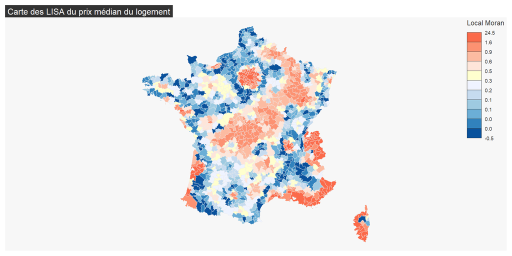

```r
library(rgeoda)

# Pour utiliser la fonction local_moran proposée par le package rgeoda 2 pré-requis:

# 1- utiliser la fonction queen_weights du package rgeoda pour calculer une matrice de contiguïté de type queen
queen_w <- queen_weights(data_immo)
# 2- Sortir la variable à étudier dans un vecteur
prix_med_z = data_immo["prix_med_z"]

lisa <- local_moran(queen_w, prix_med_z)

# Pour visualiser les résultats des LISA il faut les stocker dans des objets ou dans les base de données pour les représenter
lisa_colors <- lisa_colors(lisa)
lisa_labels <- lisa_labels(lisa)
lisa_clusters <- lisa_clusters(lisa)
lisa_value <- lisa_values(lisa)
lisa_pvalue<- lisa_pvalues(lisa)


# Carte de Moran locaux
data_immo$moranlocalvalue <- lisa_values(lisa)

cols_v2 <- c("#08519c", "#3182bd", "#6baed6", "#9ecae1", "#c6dbef", "#eff3ff", "#ffffce", "#fee5d9", "#fcbba1", "#fc9272",  "#fb6a4a", "#de2d26")

mf_map(x = data_immo,
       var = "moranlocalvalue",
       type = "choro",
       border = "#ebebeb",
       lwd = 0.1,
       pal=cols_v2,
       leg_title = "Local Moran",
       leg_val_rnd = 1)
mf_title("Carte des LISA du prix médian du logement")
```

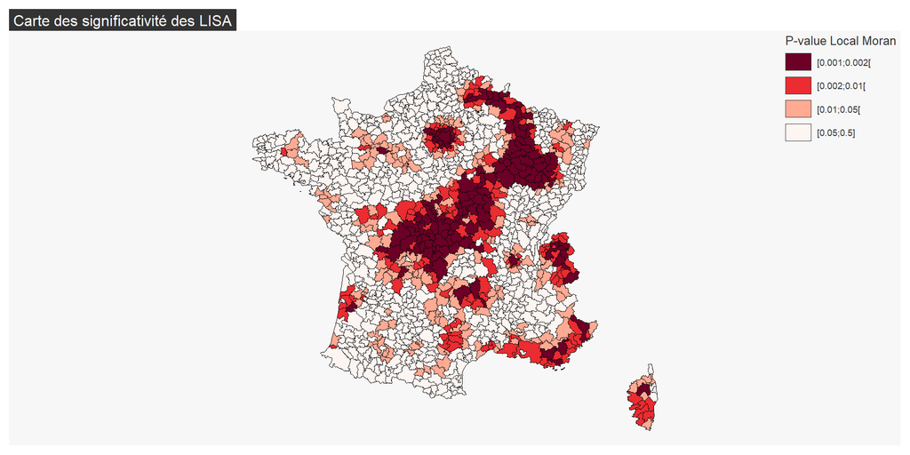

```r
# Carte des p-value des moran locaux
data_immo$moranlocalpvalue<- lisa_pvalues(lisa)

library(dplyr)

# Pour plus de lisibilité dans la carte on va faire des classes des p-value
data_immo<- data_immo %>%  mutate(lisapvalue_fac = case_when(moranlocalpvalue <= 0.002 ~ "[0.001;0.002[",
                           moranlocalpvalue <= 0.01 ~ "[0.002;0.01[",
                           moranlocalpvalue <= 0.05 ~ "[0.01;0.05[",
                           TRUE ~ "[0.05;0.5]")) %>%
  mutate(lisapvalue_fac = factor(lisapvalue_fac,
                        levels = c("[0.001;0.002[", "[0.002;0.01[",
                                   "[0.01;0.05[",
                                  "[0.05;0.5]")))

mypal <- mf_get_pal(n = 4, palette = "Reds")

mf_map(x = data_immo,
       var = "lisapvalue_fac",
       type = "typo",
       border = "grey3",
       lwd = 0.1,
       pal=mypal,
       leg_title = "P-value Local Moran")
mf_title("Carte des significativité des LISA")
```

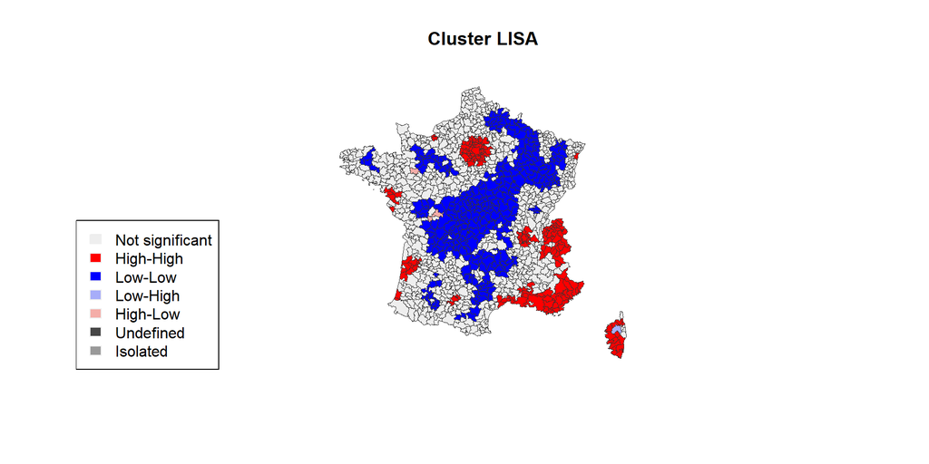

```r
# Carte des clusters lisa avec rgeoda

plot(st_geometry(data_immo),
     col=sapply(lisa_clusters, function(x){return(lisa_colors[[x+1]])}),
     border = "#333333", lwd=0.2)
title(main = "Cluster LISA")
legend('bottomleft', legend = lisa_labels, fill = lisa_colors, border = "#eeeeee")
```

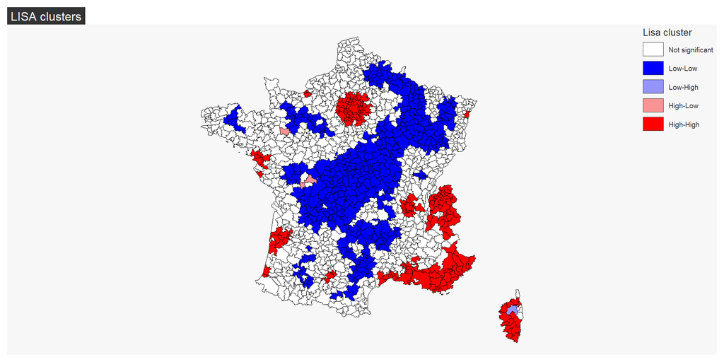

```r
# En utilisant le package mapsf

data_immo$testmoran <- sapply(lisa_clusters, function(x){return(lisa_labels[[x+1]])})

colors <- c("white","blue",rgb(0,0,1,alpha=0.4),rgb(1,0,0,alpha=0.4),"red")

mf_map(x = data_immo,
       var = "testmoran",
       type = "typo",
       border = "black",
       lwd = 0.1,
       pal= colors,
       val_order = c("Not significant","Low-Low","Low-High","High-Low","High-High"),
       leg_title = "Lisa cluster")
mf_title("LISA clusters")
```

## L’Hétérogénéité Spatiale

## Le problème de la non-stationnarité

Dans une régression classique, les **coefficients sont constants** :

$$Y_i = \beta_0 + \beta_1 X_{1i} + \beta_2 X_{2i} + \epsilon_i$$

Mais en réalité, les effets peuvent **varier dans l’espace** !

## Exemple conceptuel

**Question** : Quel est l’effet de la surface sur le prix immobilier ?

- En centre-ville : effet fort
- En périphérie : effet plus faible
- En zone rurale : effet encore différent

➜ Un seul coefficient global est **inadapté**

## Solutions possibles

1. **Variables d’interaction** : limité et arbitraire
2. **Modèles par sous-zones** : perte de continuité spatiale
3. **Geographically Weighted Regression (GWR)** :
   - Coefficients variables dans l’espace
   - Continuité spatiale préservée
   - Exploration des variations locales

## La GWR - Principes

## Définition de la GWR

**Geographically Weighted Regression** :

Méthode de régression où les coefficients **varient localement** :

$$Y_i = \beta_0(u_i, v_i) + \sum_{k}\beta_k(u_i, v_i)X_{ki} + \epsilon_i$$

- $(u_i, v_i)$ : coordonnées spatiales de i
- $\beta_k(u_i, v_i)$ : coefficient variable dans l’espace

## Principe de la GWR (1/2)

Pour chaque point i, on estime un **modèle local** :

1. Définir un **voisinage** autour de i
2. **Pondérer** les observations selon leur distance à i
3. Estimer les coefficients pour i
4. Répéter pour chaque observation

## Principe de la GWR (2/2)

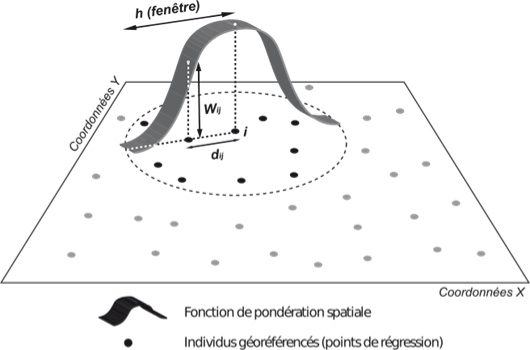

Chaque point a son propre modèle local

## Comparaison GWR vs. OLS

### Régression OLS

- 1 coefficient par variable
- R² global
- Hypothèse de stationnarité

### GWR

- n coefficients par variable
- n R² locaux
- Variation spatiale explicite

**Test** : La GWR est-elle meilleure que l’OLS ?

## Avantages de la GWR

- Capture l’**hétérogénéité spatiale**
- Permet une **analyse locale** fine
- **Exploration** des variations spatiales
- Meilleure **capacité prédictive** (souvent)

## Limites et précautions (1/2)

**Problèmes possibles** :

- **Multicolinéarité locale** : instabilité des coefficients
- **Sur-ajustement** : bandwidth trop petit
- **Autocorrélation spatiale** : résidus non indépendants
- **Interprétation** : complexité accrue

## Limites et précautions (2/2)

**Bonnes pratiques** :

1. Toujours comparer avec un modèle OLS
2. Vérifier la multicolinéarité locale
3. Analyser les résidus (autocorrélation)
4. Interpréter avec prudence
5. Croiser avec expertise du terrain

## La fonction de pondération

**Fonction gaussienne** (la plus courante) :

$$w_{ij} = \exp\left(-\frac{d_{ij}^2}{b^2}\right)$$

- $d_{ij}$ : distance entre i et j
- $b$ : **bandwidth** (largeur de bande)
- Plus on s’éloigne de i, moins le poids est important

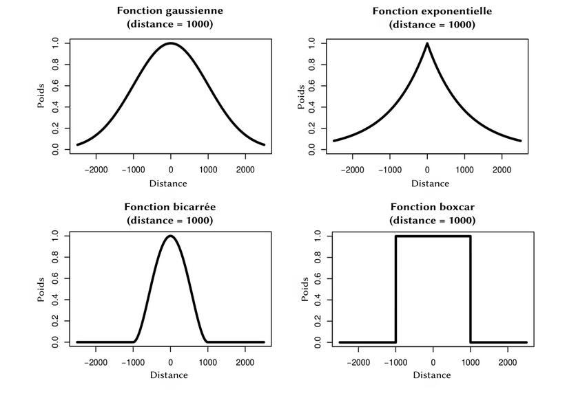

## Le paramètre clé : bandwidth

Le **bandwidth** (b) détermine la taille du voisinage :

- **b petit** : forte variation locale, risque de sur-ajustement
- **b grand** : lissage, se rapproche du modèle global
- **b optimal** : minimise un critère (AICc, CV)

## Sélection automatique du bandwidth

**Critère AICc** (Akaike Information Criterion corrigé) :

- Compromis ajustement / complexité
- Correction pour petits échantillons
- Sélection automatique possible

**Cross-validation** :

- Validation croisée
- Erreur de prédiction

## Produire une GWR avec R

Pour réaliser une GWR sur R plusieurs packages reconnus existent. On peut citer notamment le package spgwret le package `GWmodel`. Nous choisirons d’utiliser ici le package `GWmodel`.

**Note**

Attention, les fonctions de ce package ne sont pas utilisables sur des objets de type sf, il faut travailler sur des objets de type Spatial DataFrame (SpatialPointsDataFrame or SpatialPolygonsDataFrame) (contrairement à spgwr qui peut travailler avec un format sf).

```r
class(data_immo)
```

```
[1] "sf"         "data.frame"
```

```r
sp_data_immo <- as(data_immo, "Spatial")
class(sp_data_immo)
```

```
[1] "SpatialPolygonsDataFrame"
attr(,"package")
[1] "sp"
```

## Calcul de la matrice des distances

La première étape est de calculer la distance entre toutes nos observations. Pour ce faire nous utiliserons la fonction `gw.dist()`.

```r
library(GWmodel)

# Pour construire la matrice de distances entre centroïdes des EPCI :
dm.calib <- gw.dist(dp.locat = coordinates(sp_data_immo))
```

## Définition de la bande passante avec R

```r
# Définition de la bande passante (bandwidth en anglais)
# Cette fonction n'est pas compatible avec le format sf il faut un Spatial DataFrame (contrairement à spgwr qui peut travailler avec un format sf)
bw_g <- bw.gwr(data = sp_data_immo,
              approach = "AICc",
              kernel = "gaussian",
              adaptive = TRUE,
              dMat = dm.calib,
              formula = prix_med ~ perc_log_vac + perc_maison + perc_tiny_log + dens_pop + med_niveau_vis + part_log_suroccup + part_agri_nb_emploi + part_cadre_profintellec_nbemploi)
```

```
Adaptive bandwidth (number of nearest neighbours): 763 AICc value: 17959.04
Adaptive bandwidth (number of nearest neighbours): 480 AICc value: 17884.14
Adaptive bandwidth (number of nearest neighbours): 303 AICc value: 17798.07
Adaptive bandwidth (number of nearest neighbours): 196 AICc value: 17715.24
Adaptive bandwidth (number of nearest neighbours): 127 AICc value: 17622.76
Adaptive bandwidth (number of nearest neighbours): 87 AICc value: 17526.89
Adaptive bandwidth (number of nearest neighbours): 59 AICc value: 17422.28
Adaptive bandwidth (number of nearest neighbours): 45 AICc value: 17353.68
Adaptive bandwidth (number of nearest neighbours): 33 AICc value: 17283.09
Adaptive bandwidth (number of nearest neighbours): 29 AICc value: 17261.83
Adaptive bandwidth (number of nearest neighbours): 23 AICc value: 17250.23
Adaptive bandwidth (number of nearest neighbours): 22 AICc value: 17247.23
Adaptive bandwidth (number of nearest neighbours): 19 AICc value: 17201.79
Adaptive bandwidth (number of nearest neighbours): 19 AICc value: 17201.79
```

## Estimation du modèle

Une fois la bande passante définie, on peut lancer l’estimation de notre modèle de GWR :

```r
mod.gwr_g <- gwr.robust(data = sp_data_immo,
                   dMat = dm.calib,
                   bw = bw_g,
                   kernel = "gaussian",
                   filtered = FALSE, # un des problèmes de la GWR est de gérer des individus "aberrants" au niveau local. 2 méthodes ont été définies pour gérer cela.
                                    # Méthode 1 (argument TRUE) on filtre en fonction des individus standardisés. L'objectif est de détecter les individus dont les résidus sont très élevés et de les exclure.
                                    # Methode 2 (argument FALSE) on diminue le poids des observations aux résidus élevés.
                   adaptive = TRUE,
                   formula = prix_med ~ perc_log_vac + perc_maison + perc_tiny_log + dens_pop + med_niveau_vis + part_log_suroccup + part_agri_nb_emploi + part_cadre_profintellec_nbemploi)
```

## Comparer les modèless

Si on souhaite comparer deux modèles car nous avons un doute sur les paramètres c’est tout à fait possible. Par exemple ici nous souhaitons comparer deux formes de noyaux.

```r
bw_tri <- bw.gwr(data = sp_data_immo,
              approach = "AICc",
              kernel = "tricube",
              adaptive = TRUE,
              dMat = dm.calib,
              formula = prix_med ~ perc_log_vac + perc_maison + perc_tiny_log + dens_pop + med_niveau_vis + part_log_suroccup + part_agri_nb_emploi + part_cadre_profintellec_nbemploi)
```

```
Adaptive bandwidth (number of nearest neighbours): 763 AICc value: 17701.17
Adaptive bandwidth (number of nearest neighbours): 480 AICc value: 17586.94
Adaptive bandwidth (number of nearest neighbours): 303 AICc value: 17422.51
Adaptive bandwidth (number of nearest neighbours): 196 AICc value: 17294.75
Adaptive bandwidth (number of nearest neighbours): 127 AICc value: 17254.1
Adaptive bandwidth (number of nearest neighbours): 87 AICc value: 17279.33
Adaptive bandwidth (number of nearest neighbours): 154 AICc value: 17259.05
Adaptive bandwidth (number of nearest neighbours): 112 AICc value: 17257.17
Adaptive bandwidth (number of nearest neighbours): 138 AICc value: 17254.8
Adaptive bandwidth (number of nearest neighbours): 122 AICc value: 17253.75
Adaptive bandwidth (number of nearest neighbours): 117 AICc value: 17255.04
Adaptive bandwidth (number of nearest neighbours): 123 AICc value: 17253.57
Adaptive bandwidth (number of nearest neighbours): 126 AICc value: 17254.25
Adaptive bandwidth (number of nearest neighbours): 123 AICc value: 17253.57
```

```r
mod.gwr_tri <- gwr.robust(data = sp_data_immo,
                   dMat = dm.calib,
                   bw = bw_tri,
                   kernel = "gaussian",
                   filtered = FALSE,
                   adaptive = TRUE,
                   formula = prix_med ~ perc_log_vac + perc_maison + perc_tiny_log + dens_pop + med_niveau_vis + part_log_suroccup + part_agri_nb_emploi + part_cadre_profintellec_nbemploi)

Best_gwr <- cbind(
  rbind(bw_g, bw_tri),
  rbind(mod.gwr_g$GW.diagnostic$gw.R2,mod.gwr_tri$GW.diagnostic$gw.R2),
  rbind(mod.gwr_g$GW.diagnostic$AIC,mod.gwr_tri$GW.diagnostic$AIC)) %>%
  `colnames<-`(c("Nb Voisins","R2","AIC")) %>%
  `rownames<-`(c("GAUSSIAN","TRICUBE"))

Best_gwr
```

```
         Nb Voisins        R2      AIC
GAUSSIAN         19 0.9324328 16849.26
TRICUBE         123 0.8577370 17567.05
```

## La GWR - Interprétation

## Résultats de la GWR

Pour chaque observation, on obtient :

1. **Coefficients locaux** pour chaque variable
2. **R² local** : qualité de l’ajustement local
3. **Résidus** : erreurs de prédiction
4. **Tests de significativité**

## Visualisation des coefficients

**Cartographie des coefficients** :

- Une carte par variable explicative
- Identifier les zones de forte/faible influence
- Comprendre les variations spatiales des relations

## Interprétation des premiers résultats

Comme pour le modèle linéaire classique l’objet qui contient notre GWR est composé de plusieurs éléments. A la différence du modèle classique pour obtenir nos résultats il suffit d’appeler l’objet :

```r
# Pour voir les différents éléments qui composent notre modèle de GWR
summary(mod.gwr_g)
```

```
              Length Class                    Mode
GW.arguments    11   -none-                   list
GW.diagnostic    8   -none-                   list
lm              14   lm                       list
SDF           1223   SpatialPolygonsDataFrame S4
timings          5   -none-                   list
this.call       15   -none-                   call
Ftests           0   -none-                   list
```

Pour accéder aux résultats :

```r
mod.gwr_g
```

```
   *                       Package   GWmodel                             *
   Program starts at: 2026-02-27 19:41:28.175683
   Call:
   gwr.basic(formula = formula, data = data, bw = bw, kernel = kernel,
    adaptive = adaptive, p = p, theta = theta, longlat = longlat,
    dMat = dMat, F123.test = F123.test, cv = T, W.vect = W.vect,
    parallel.method = parallel.method, parallel.arg = parallel.arg)

   Dependent (y) variable:  prix_med
   Independent variables:  perc_log_vac perc_maison perc_tiny_log dens_pop med_niveau_vis part_log_suroccup part_agri_nb_emploi part_cadre_profintellec_nbemploi
   Number of data points: 1223
   *                    Results of Global Regression                     *

   Call:
    lm(formula = formula, data = data)

   Residuals:
    Min      1Q  Median      3Q     Max
-1566.8  -220.2   -27.2   174.0  3277.3

   Coefficients:
                                    Estimate Std. Error t value Pr(>|t|)
   (Intercept)                      1592.873     11.204 142.171  < 2e-16 ***
   perc_log_vac                     -287.337     14.134 -20.330  < 2e-16 ***
   perc_maison                      -128.255     20.041  -6.400 2.22e-10 ***
   perc_tiny_log                    -261.556     27.934  -9.363  < 2e-16 ***
   dens_pop                          173.942     15.272  11.389  < 2e-16 ***
   med_niveau_vis                    288.017     13.860  20.781  < 2e-16 ***
   part_log_suroccup                 388.982     27.352  14.221  < 2e-16 ***
   part_agri_nb_emploi               -20.785     15.059  -1.380    0.168
   part_cadre_profintellec_nbemploi   -7.841     19.904  -0.394    0.694

   ---Significance stars
   Signif. codes:  0 '***' 0.001 '**' 0.01 '*' 0.05 '.' 0.1 ' ' 1
   Residual standard error: 391.8 on 1214 degrees of freedom
   Multiple R-squared: 0.7784
   Adjusted R-squared: 0.7769
   F-statistic: 532.9 on 8 and 1214 DF,  p-value: < 2.2e-16
   ***Extra Diagnostic information
   Residual sum of squares: 186354789
```

[output cut: 30 more lines]

```
   part_log_suroccup                  247.33650  700.50
   part_agri_nb_emploi                 -1.15602  120.33
   part_cadre_profintellec_nbemploi    49.93194  388.50
   ************************Diagnostic information*************************
   Number of data points: 1223
   Effective number of parameters (2trace(S) - trace(S'S)): 320.246
   Effective degrees of freedom (n-2trace(S) + trace(S'S)): 902.754
   AICc (GWR book, Fotheringham, et al. 2002, p. 61, eq 2.33): 17201.79
   AIC (GWR book, Fotheringham, et al. 2002,GWR p. 96, eq. 4.22): 16849.26
   BIC (GWR book, Fotheringham, et al. 2002,GWR p. 61, eq. 2.34): 17068.01
   Residual sum of squares: 56808914
   R-square value:  0.9324328
   Adjusted R-square value:  0.9084372

   Program stops at: 2026-02-27 19:41:39.380692
```

## Visualiser les résultats

```r
# Pour visualiser ce fichier dans R
#View(mod.gwr_g$SDF@data)

#Pour voir à quoi il ressemble de manière interactive
datatable(mod.gwr_g$SDF@data)
```

|  | Intercept | perc_log_vac | perc_maison | perc_tiny_log | dens_pop | med_niveau_vis | part_log_suroccup | part_agri_nb_emploi | part_cadre_profintellec_nbemploi | y | yhat | residual | CV_Score | Stud_residual | Intercept_SE | perc_log_vac_SE | perc_maison_SE | perc_tiny_log_SE | dens_pop_SE | med_niveau_vis_SE | part_log_suroccup_SE | part_agri_nb_emploi_SE | part_cadre_profintellec_nbemploi_SE | Intercept_TV | perc_log_vac_TV | perc_maison_TV | perc_tiny_log_TV | dens_pop_TV | med_niveau_vis_TV | … |
| --- | --- | --- | --- | --- | --- | --- | --- | --- | --- | --- | --- | --- | --- | --- | --- | --- | --- | --- | --- | --- | --- | --- | --- | --- | --- | --- | --- | --- | --- | --- |
| 1 | 1518.261915008521 | -848.2740736226207 | -100.1789791735251 | -116.9891535934662 | 23.83373142065966 | 165.9747702153052 | 179.7323382271276 | -357.6906036494051 | 156.9678454642217 | 2550 | 2699.958341162497 | -149.9583411624972 | -203.6076029501555 | -0.770951392734931 | 85.6771773545011 | 59.5664635299282 | 69.35730816554157 | 91.98099152278213 | 136.8026593147105 | 26.80854701272698 | 78.61567172664523 | 136.4098594300231 | 60.62856735953949 | 17.72072752498024 | -14.24079966064158 | -1.444389665965966 | -1.271884023608182 | 0.1742197961651525 | 6.191113980795417 | … |
| 2 | 1898.763285216225 | -257.5228007865236 | -461.9951831380142 | -393.9318323355485 | 248.0122244303645 | 499.3567108509678 | 208.4468485674054 | -17.14287202883702 | -32.4613847632063 | 1640 | 1715.7458463602 | -75.7458463602004 | -87.6154918589275 | -0.3360649834848379 | 82.70846095485773 | 70.67187525809277 | 109.7383969734993 | 129.8192516864171 | 143.3893396531902 | 123.4855733922317 | 184.0420616117263 | 92.8893028506045 | 107.6491847249869 | 22.95730404477687 | -3.643921996495122 | -4.209968396472761 | -3.03446389667308 | 1.729642001492031 | 4.043846557401837 | … |
| 3 | 1289.335363271782 | -77.8620131748128 | 298.2288126216031 | 301.0487436790413 | 271.6690011963078 | 417.1435445538516 | 121.1378859521616 | -66.4923832120819 | -21.74538050755609 | 830 | 850.893275817605 | -20.89327581760494 | -24.97842319442896 | -0.09461283470231703 | 35.63398361195286 | 40.56381325510494 | 87.53489657957464 | 90.02514598636904 | 16.2605337251342 | 36.59084920800715 | 59.9789003662971 | 39.15610959479391 | 43.75029188672778 | 36.18274558669592 | -1.919494419450664 | 3.406970525754773 | 3.344051713336004 | 16.70726224541967 | 11.40021490571387 | … |
| 4 | 2052.985008331762 | -94.54658211006796 | 144.4040713600398 | -75.63614256526988 | -35.82313244646582 | 508.5905804485465 | 540.9206102376777 | -123.2392661552913 | -97.41030632074694 | 1630 | 1680.221457209636 | -50.22145720963613 | -65.34681964064634 | -0.2418800863235744 | 57.63336133289713 | 60.46830569246157 | 78.06725142718464 | 108.3240953286913 | 164.3484394800305 | 80.58049900105705 | 117.1244543366181 | 59.84943741396282 | 78.9635725614146 | 35.62146924718615 | -1.563572536510724 | 1.849739406987182 | -0.6982393191077633 | -0.2179706272831302 | 6.311583903716889 | … |
| 5 | 1270.52697605896 | -96.95622730500011 | 130.6332817614269 | 136.6497199245555 | 262.9711598229163 | 411.3902574633382 | 142.2321374081839 | -45.52928794062842 | -43.98166159267475 | 1300 | 1176.995921953795 | 123.0040780462048 | 142.3049278135968 | 0.5459314030481887 | 66.16209791609391 | 41.54703465837733 | 129.4969939647515 | 119.4404723197318 | 20.17739623754702 | 42.25116931677889 | 92.13540955836285 | 48.71412873558614 | 50.67422325962826 | 19.2032450009404 | -2.33364975628773 | 1.008774626822494 | 1.144082213261482 | 13.03295810455303 | 9.736778037524417 | … |
| 6 | 1292.559724130002 | -202.5412890847641 | 118.9389116326021 | 198.6429580428485 | -6.045694319649431 | 275.0980130100336 | 17.9013677624041 | -81.23765982884295 | 15.75617853215553 | 1830 | 1799.696240612812 | 30.30375938718839 | 37.71746370654273 | 0.1409177450439542 | 53.55584838789528 | 52.43351936253877 | 91.27189479611293 | 152.941537558006 | 178.8487898264739 | 47.6656406624823 | 187.2584762291331 | 69.75299070892895 | 63.87204270264598 | 24.13480064339989 | -3.862820797595937 | 1.303127451208205 | 1.298816274601067 | -0.03380338399558196 | 5.771411213330521 | … |
| 7 | 1279.906621198524 | -95.56931184886842 | 66.07820168809496 | 45.1238680765818 | 244.5614911585182 | 384.4628137778283 | 173.113511713266 | -50.88455463390432 | -24.02130314115345 | 890 | 906.3508864359258 | -16.35088643592576 | -17.82562920694613 | -0.06943192488081419 | 72.06517303810828 | 47.24196527689938 | 136.1481684305567 | 141.6012623589177 | 26.97012296168447 | 58.24397006122959 | 110.0668118236712 | 47.18758796438545 | 62.56449053711439 | 17.76040446779619 | -2.022974939520571 | 0.4853403644706288 | 0.3186685438029926 | 9.06786711747508 | 6.600903293056049 | … |
| 8 | 1970.994329068156 | -390.3923910858481 | 244.034638962728 | -153.2382806391354 | -40.47468922405739 | 420.812255701991 | 590.8361619475944 | -332.3453213538869 | -92.82405791960537 | 3090 | 3450.591633402814 | -360.5916334028138 | -510.2717447087862 | -1.877152077257656 | 63.15191776717908 | 79.70439082299161 | 59.05493947830516 | 87.39054854354502 | 74.41615716005678 | 86.18234840420642 | 60.00132253138385 | 82.47008266291532 | 56.59648860012349 | 31.21036381404254 | -4.898003573640451 | 4.132332386055163 | -1.75348802808784 | -0.5438965242051274 | 4.882812588586317 | … |
| 9 | 1246.595520029341 | -95.02742573438987 | 202.9158697446962 | 200.1143479434368 | 268.0758323706223 | 418.6631727866175 | 145.0888029867845 | -45.27717764283011 | -52.6921937172533 | 1710 | 1739.945813365757 | -29.9458133657572 | -41.16655673023934 | -0.153407053615604 | 64.92194080017074 | 40.96490149112144 | 125.0272407346999 | 111.7813591589642 | 18.55549866583044 | 37.6760687604067 | 85.54964863393735 | 51.50147991794846 | 45.20907400209395 | 19.20145184609241 | -2.319727920131474 | 1.622973270083366 | 1.790230047738588 | 14.4472448409203 | 11.11217774468511 | … |
| 10 | 1172.915989052673 | -125.8273207743264 | -258.8005755125718 | -79.4976005080465 | 8.027843749194574 | 391.2668990729942 | 78.81657863688773 | -29.31989972225011 | 37.81628948958496 | 960 | 621.9408571410977 | 338.0591428589023 | 401.2079108497193 | 1.523460113543491 | 56.5353027397252 | 48.38288707409502 | 86.31020870957425 | 132.9724472203073 | 96.2376006958764 | 43.80592596276073 | 165.6465923818703 | 53.55479745043225 | 60.52788305247623 | 20.74661197893453 | -2.600657554428917 | -2.998493218611154 | -0.5978501724972825 | 0.08341691491835532 | 8.931825785525202 | … |

[output cut: 1213 more lines]

```r
# Pour voir les variables qui le constituent
names(mod.gwr_g$SDF@data)
```

```
 [1] "Intercept"                           "perc_log_vac"
 [3] "perc_maison"                         "perc_tiny_log"
 [5] "dens_pop"                            "med_niveau_vis"
 [7] "part_log_suroccup"                   "part_agri_nb_emploi"
 [9] "part_cadre_profintellec_nbemploi"    "y"
[11] "yhat"                                "residual"
[13] "CV_Score"                            "Stud_residual"
[15] "Intercept_SE"                        "perc_log_vac_SE"
[17] "perc_maison_SE"                      "perc_tiny_log_SE"
[19] "dens_pop_SE"                         "med_niveau_vis_SE"
[21] "part_log_suroccup_SE"                "part_agri_nb_emploi_SE"
[23] "part_cadre_profintellec_nbemploi_SE" "Intercept_TV"
[25] "perc_log_vac_TV"                     "perc_maison_TV"
[27] "perc_tiny_log_TV"                    "dens_pop_TV"
[29] "med_niveau_vis_TV"                   "part_log_suroccup_TV"
[31] "part_agri_nb_emploi_TV"              "part_cadre_profintellec_nbemploi_TV"
[33] "E_weigts"                            "Local_R2"
```

## Représenter nos résidus de la GWR

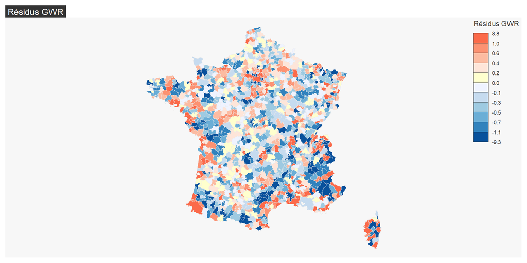

```r
res_gwr <- mod.gwr_g$SDF$Stud_residual
data_immo$res_gwr <- res_gwr

# carto résidus v2
mf_map(x = data_immo,
       var = "res_gwr",
       type = "choro",
       border = "#ebebeb",
       lwd = 0.1,
       breaks = quantile(data_immo$res_gwr, seq(0,1, by=1/11)),
       pal = cols_v2,
       leg_title = "Résidus GWR",
       leg_val_rnd = 1)
mf_title("Résidus GWR")
```

## Etude des coefficients

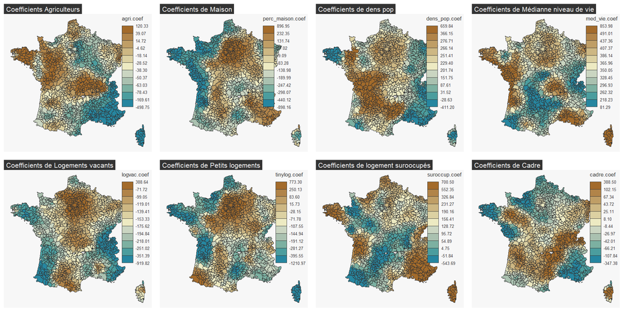

```r
# On ajoute à data_immo les coefficients

data_immo$agri.coef=mod.gwr_g$SDF$part_agri_nb_emploi
data_immo$perc_maison.coef <- mod.gwr_g$SDF$perc_maison
data_immo$dens_pop.coef=mod.gwr_g$SDF$dens_pop
data_immo$med_vie.coef=mod.gwr_g$SDF$med_niveau_vis
data_immo$logvac.coef=mod.gwr_g$SDF$perc_log_vac
data_immo$tinylog.coef=mod.gwr_g$SDF$perc_tiny_log
data_immo$suroccup.coef=mod.gwr_g$SDF$part_log_suroccup
data_immo$cadre.coef=mod.gwr_g$SDF$part_cadre_profintellec_nbemploi

# Réaliser la collection des cartes

par(mfrow = c(2, 4))

mf_map(x = data_immo, var = "agri.coef", type = "choro", pal= "Earth")
mf_title("Coefficients Agriculteurs")

mf_map(x = data_immo, var = "perc_maison.coef", type = "choro", pal= "Earth")
mf_title("Coefficients de Maison")

mf_map(x = data_immo, var = "dens_pop.coef", type = "choro", pal= "Earth")
mf_title("Coefficients de dens pop")

mf_map(x = data_immo, var = "med_vie.coef", type = "choro", pal= "Earth")
mf_title("Coefficients de Médianne niveau de vie")

mf_map(x = data_immo, var = "logvac.coef", type = "choro", pal= "Earth")
mf_title("Coefficients de Logements vacants")

mf_map(x = data_immo, var = "tinylog.coef", type = "choro", pal= "Earth")
mf_title("Coefficients de Petits logements")

mf_map(x = data_immo, var = "suroccup.coef", type = "choro", pal= "Earth")
mf_title("Coefficients de logement suroocupés")

mf_map(x = data_immo, var = "cadre.coef", type = "choro", pal= "Earth")
mf_title("Coefficients de Cadre")
```

## Contribution max

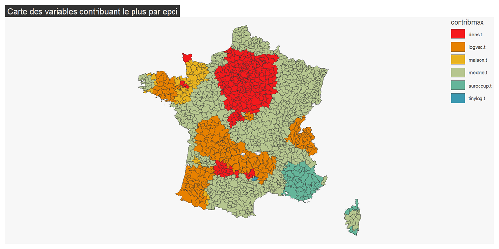

```r
data_immo$agri.t <- mod.gwr_g$SDF$part_agri_nb_emploi_TV
data_immo$maison.t <- mod.gwr_g$SDF$perc_maison_TV
data_immo$dens.t <- mod.gwr_g$SDF$dens_pop_TV
data_immo$medvie.t <- mod.gwr_g$SDF$med_niveau_vis_TV
data_immo$logvac.t <- mod.gwr_g$SDF$perc_log_vac_TV
data_immo$tinylog.t <- mod.gwr_g$SDF$perc_tiny_log_TV
data_immo$suroccup.t <- mod.gwr_g$SDF$part_log_suroccup_TV
data_immo$cadre.t <- mod.gwr_g$SDF$part_cadre_profintellec_nbemploi_TV

#Définir contrib max
df<- as.data.frame(data_immo)
# On passe les t-values en valeurs absolues pour voir la plus grande contribution dans un sens sens ou dans l'autre
data_immo$contribmax<- colnames(df[, c(30:37)])[max.col(abs(df[, c(30:37)]),ties.method="first")]


par(mfrow = c(1, 1))

# Carte
mf_map(x = data_immo, var = "contribmax", type = "typo", pal= "Zissou 1")
mf_title("Carte des variables contribuant le plus par epci")
```

## Cartographier les R2

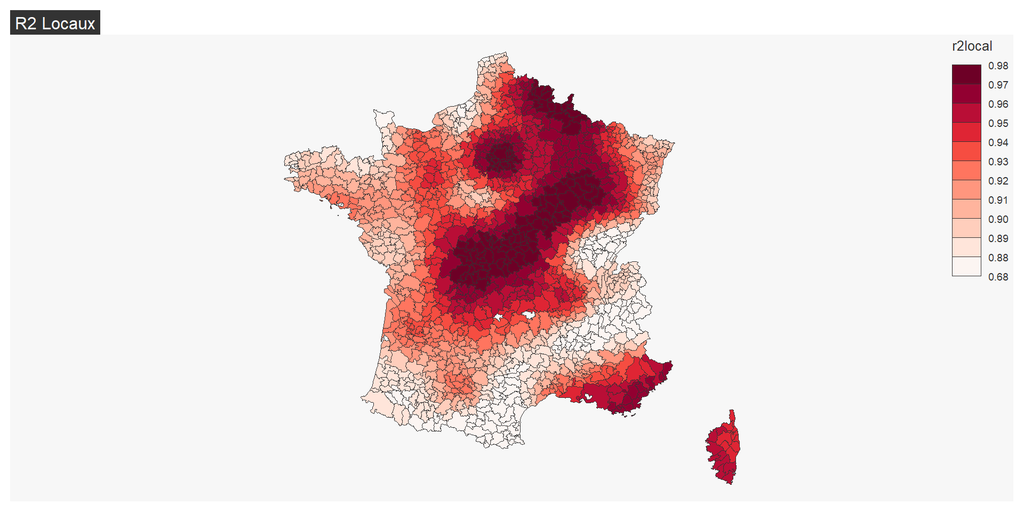

```r
data_immo$r2local=mod.gwr_g$SDF$Local_R2

mf_map(x = data_immo, var = "r2local", type = "choro", pal= "Reds")
mf_title("R2 Locaux")
```

## Les t-value et p-value

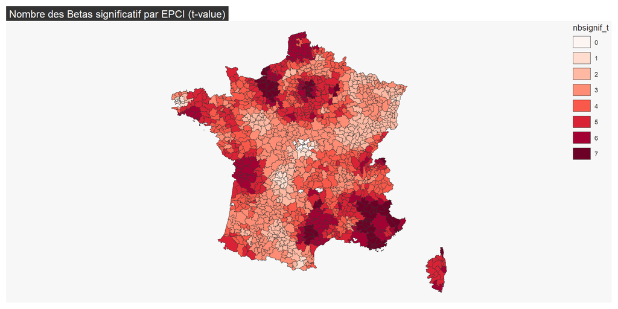

```r
# Pour rappel si on a plus de 200 individus et le t-value > |1.96| on pourra considérer le coefficient comme significatif au seuil de 0.05 (95% chances que ce ne soit pas dû au hasard)

data_immo$nbsignif_t<- rowSums(abs(df[, c(30:37)]) > 1.96)

mf_map(x = data_immo, var = "nbsignif_t", type = "typo", pal= "Reds")
mf_title("Nombre des Betas significatif par EPCI (t-value)")
```

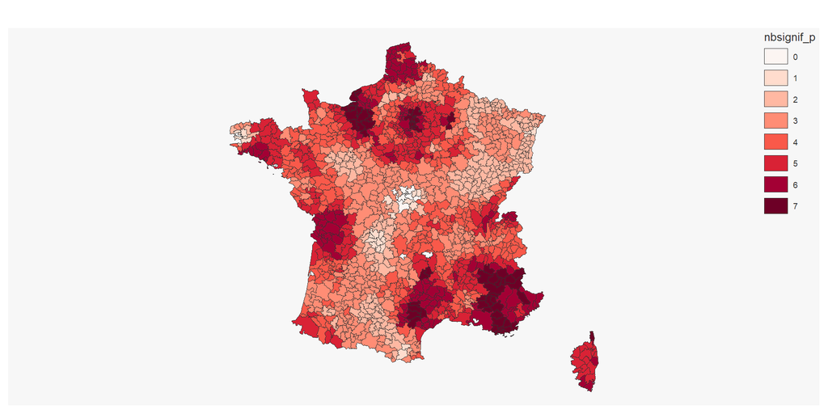

```r
#  Les p-value ne sont pas fournit dans le modèle de la GWR, on pourrait les calculer à partir de t-value et de l'erreur standard mais le package GWmodel propose une fonction pour les obttenir

pvalue<-gwr.t.adjust(mod.gwr_g)

# On ajoute les p-value à notre fichier
data_immo$agri.p <- pvalue$SDF$part_agri_nb_emploi_p
data_immo$maison.p <- pvalue$SDF$perc_maison_p
data_immo$dens.p <- pvalue$SDF$dens_pop_p
data_immo$medvie.p <- pvalue$SDF$med_niveau_vis_p
data_immo$logvac.p <- pvalue$SDF$perc_log_vac_p
data_immo$tinylog.p <- pvalue$SDF$perc_tiny_log_p
data_immo$suroccup.p <- pvalue$SDF$part_log_suroccup_p
data_immo$cadre.p <- pvalue$SDF$part_cadre_profintellec_nbemploi_p

df<- as.data.frame(data_immo)
data_immo$nbsignif_p<- rowSums(df[, c(41:48)] < 0.05)

mf_map(x = data_immo, var = "nbsignif_p", type = "typo", pal= "Reds")
```

## P-value par variable

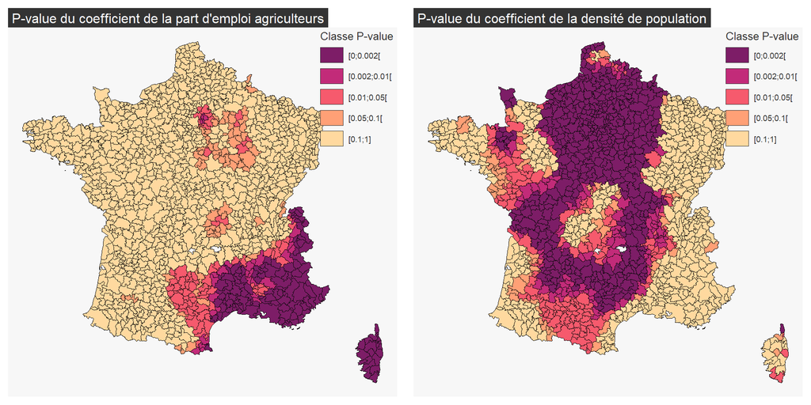

```r
# Ici nous représenterons les p-value avec un decoupage par classe de significativité et seulement les p-value de 2 VI

par(mfrow = c(1, 2))

# Par exemple les p-value des coefficients de la variable part de l'emploi agriculteur
data_immo<- data_immo %>%  mutate(agri.p_fac = case_when(agri.p <= 0.002 ~ "[0;0.002[",
                           agri.p <= 0.01 ~ "[0.002;0.01[",
                           agri.p <= 0.05 ~ "[0.01;0.05[",
                           agri.p <= 0.1 ~ "[0.05;0.1[",
                           TRUE ~ "[0.1;1]")) %>%
  mutate(agri.p_fac = factor(agri.p_fac,
                        levels = c("[0;0.002[", "[0.002;0.01[",
                                   "[0.01;0.05[",
                                  "[0.05;0.1[", "[0.1;1]")))

mypal2 <- mf_get_pal(n = 5, palette = "SunsetDark")

mf_map(x = data_immo,
       var = "agri.p_fac",
       type = "typo",
       border = "grey3",
       lwd = 0.1,
       pal=mypal2,
       leg_title = "Classe P-value")
mf_title("P-value du coefficient de la part d'emploi agriculteurs")

# Pour la densité de population
data_immo<- data_immo %>%  mutate(dens.p_fac = case_when(dens.p<= 0.002 ~ "[0;0.002[",
                           dens.p <= 0.01 ~ "[0.002;0.01[",
                           dens.p <= 0.05 ~ "[0.01;0.05[",
                           dens.p <= 0.1 ~ "[0.05;0.1[",
                           TRUE ~ "[0.1;1]")) %>%
  mutate(dens.p_fac = factor(dens.p_fac,
                        levels = c("[0;0.002[", "[0.002;0.01[",
                                   "[0.01;0.05[",
                                  "[0.05;0.1[", "[0.1;1]")))

mf_map(x = data_immo,
       var = "dens.p_fac",
       type = "typo",
       border = "grey3",
       lwd = 0.1,
       pal=mypal2,
       leg_title = "Classe P-value")
mf_title("P-value du coefficient de la densité de population")
```

# VIII. Extensions de la GWR

## MGWR : Multiscale GWR

**Idée** : différentes variables peuvent varier à différentes échelles

- Bandwidth **spécifique** par variable
- Certaines variables à effet global
- D’autres à effet local

$$Y_i = \sum_{k}\beta_k(u_i, v_i, b_k)X_{ki} + \epsilon_i$$

## GWRSAR : GWR avec autocorrélation

Combine GWR et modèles d’autocorrélation spatiale :

- Gère simultanément hétérogénéité ET autocorrélation
- Modèle plus complexe
- Package R : `mgwrsar`